# Lab 7 - Multiple Regression

key

2022-10-13

## Load data

First we load the necessary packages:

```r
library(tidyverse)
library(moderndive)

# The broom package lets us manipulate model objects and makes it easier to
# generate predictions and plot them
library(broom)
```

Then we load the data. The data is already precleaned and tidy and ready to use, so we don’t have to do any wrangling here.

```r
results_2016 <- read_csv("data/results_2016.csv")
```

## 2016 US Presidential Election

Let’s explore variation in democratic party vote share in 2016. Our main outcome variable (or y) is `percent_dem`, which is the percent of presidential votes cast for the Democratic party (on a scale of 0–100). Here’s a histogram to give you a sense of the data. King County, Texas only had 3% of its presidential votes cast for Hilary Clinton, while 90% of Washington, DC voted for her.

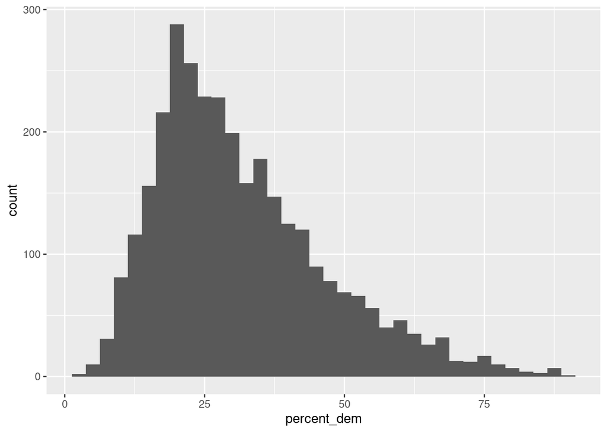

```r
ggplot(data = results_2016, aes(x = percent_dem)) +
  geom_histogram(binwidth = 2.5)
```

### Percent democratic explained by age

Let’s first test the old adage that people become more conservative as they get older. The correlation between a county’s median and age and the democratic vote share is moderately negative:

```r
results_2016 %>%
  # There are some missing values in each of these columns, so we have to filter
  # them out first before checking the correlation
  filter(!is.na(percent_dem), !is.na(median_age)) %>%
  get_correlation(percent_dem ~ median_age)
```

```
## # A tibble: 1 × 1
##      cor
##    <dbl>
## 1 -0.298
```

It looks negative too:

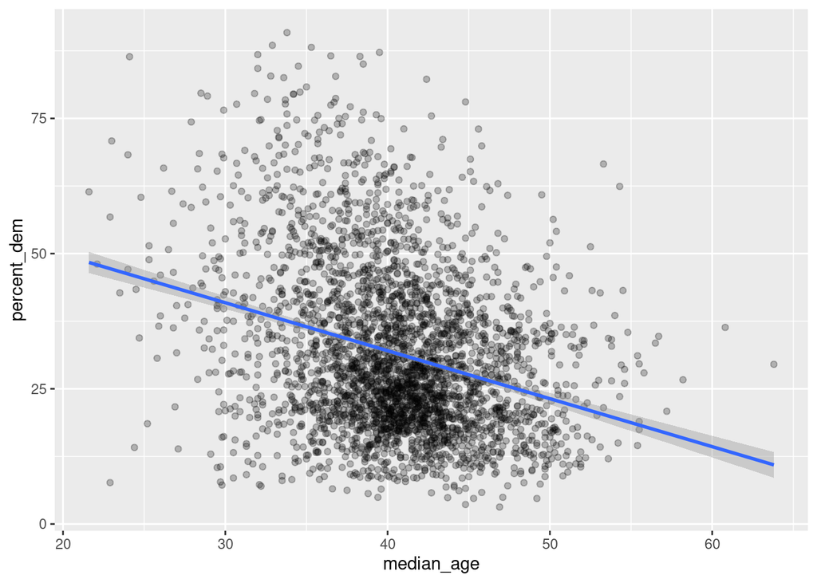

```r
ggplot(results_2016, aes(x = median_age, y = percent_dem)) +
  geom_point(alpha = 0.25) +
  geom_smooth(method = "lm")
```

If we run a regression model, we can find the slope and $R^2$ and other information.

**Run a regression model where the outcome is percent_dem and the explanatory variable is median_age). Use the $get_regression_table()$ function to see your results:**

```r
us_dem_age <- lm(percent_dem ~ median_age, data = results_2016)

get_regression_table(us_dem_age)
```

```
## # A tibble: 2 × 7
##   term       estimate std_error statistic p_value lower_ci upper_ci
##   <chr>         <dbl>     <dbl>     <dbl>   <dbl>    <dbl>    <dbl>
## 1 intercept    67.5       2.09       32.4       0   63.4     71.6
## 2 median_age   -0.887     0.051     -17.4       0   -0.987   -0.787
```

**Report and interpret the intercept:** The intercept here ($\beta_0$) means that in a hypothetical county where the median age is 0 years, the predicted democratic vote share would be 67.5%. That’s impossible though, because no counties consist entirely of babies. So we can ignore it.

**Report and Interpret the coefficient (slope) for median age:**

The slope for median age ($\beta_1$) is -0.887. This means that on average, a 1 year increase in the median age in a county is associated with a drop in democratic vote share of 0.887%. Or in other words, if a county that had 40% voting for democrats got a year older, we could predict a democratic vote share of 39.113% (40 − 0.887).

**Use the $get_regression_summaries()$ function to find the $R^2$ value for the model you just ran:**

```r
get_regression_summaries(us_dem_age)
```

```
## # A tibble: 1 × 9
##   r_squared adj_r_squared   mse  rmse sigma statistic p_value    df  nobs
##       <dbl>         <dbl> <dbl> <dbl> <dbl>     <dbl>   <dbl> <dbl> <dbl>
## 1     0.089         0.088  212.  14.6  14.6      302.       0     1  3111
```

**Report and interpret the $R^2$ value:** The $R^2$ is 0.089 (we use the regular $R^2$ because we only have one explanatory variable), which means that this model explains 8.9% of the variation in democratic vote share. It’s not that great of a model.

### Percent democratic explained by age and race

We can improve the model by including additional explanatory variables. Copy and paste the code you used above and add the $percent_white$ variable to your regression. :

```r
model_age_dem_race <- lm(percent_dem ~ median_age + percent_white,
                         data = results_2016)

get_regression_table(model_age_dem_race)
```

```
## # A tibble: 3 × 7
##   term          estimate std_error statistic p_value lower_ci upper_ci
##   <chr>            <dbl>     <dbl>     <dbl>   <dbl>    <dbl>    <dbl>
## 1 intercept       70.4       1.76      39.9    0       66.9     73.8
## 2 median_age      -0.094     0.049     -1.93   0.053   -0.189    0.001
## 3 percent_white   -0.448     0.013    -35.3    0       -0.473   -0.423
```

```r
get_regression_summaries(model_age_dem_race)
```

```
## # A tibble: 1 × 9
##   r_squared adj_r_squared   mse  rmse sigma statistic p_value    df  nobs
##       <dbl>         <dbl> <dbl> <dbl> <dbl>     <dbl>   <dbl> <dbl> <dbl>
## 1      0.35         0.349  151.  12.3  12.3      836.       0     2  3111
```

**Interpret the coefficients for median_age and percent_white:**

Now we have two coefficients to work through (again, the intercept is nonsensical; it shows what the democratic vote share would be if the median age were 0 and if the percent of white people in a county were 0%).

The slope for median age ($\beta_1$) is -0.094, which means that controlling for race, a 1 year increase in age is associated with a decrease in democratic vote share of 0.094, on average. This means that in a hypothetical county where 40% voted for democrats, we could predict that bumping age up by a year would result in 39.906%. That’s a tiny effect—controlling for race took away most of the effect of age from the previous model.

The coefficient for percent white ($\beta_2$) is -0.448, which means that controlling for age, a 1% increase in the proportion of whites in a county is associated with a drop in democratic vote share of 0.448, on average. This would be like moving from 40% to 39.552%.

**Interpret the $R^2$ for the new model. Is it better or worse than the previous model?** To explain model fit, we need to look at the adjusted $R^2$ because we’re using more than one explanatory variable. This model explains 34.9% of the variation in democratic vote share. It’s getting better!

### Percent democratic explained by lots of things

Now let’s add several more variables to the model. This time add per_capita_income, median_rent, and state to the model (in addition to median_age and percent_white):

```r
everything_model <- lm(percent_dem ~ median_age + percent_white +
                            per_capita_income + median_rent + state,
                          data = results_2016)

get_regression_table(everything_model)
```

```
## # A tibble: 54 × 7
##    term               estimate std_error statistic p_value lower_ci upper_ci
##    <chr>                 <dbl>     <dbl>     <dbl>   <dbl>    <dbl>    <dbl>
##  1 intercept            58.5       1.66      35.3    0       55.2     61.8
##  2 median_age            0.166     0.037      4.52   0        0.094    0.238
##  3 percent_white        -0.682     0.011    -61.9    0       -0.704   -0.661
##  4 per_capita_income     0         0          5.46   0        0        0
##  5 median_rent           0.02      0.002     12.3    0        0.017    0.023
##  6 state: Arizona       -7.96      2.18      -3.65   0      -12.2     -3.69
##  7 state: Arkansas       4.08      1.28       3.19   0.001    1.57     6.58
##  8 state: California    -2.45      1.50      -1.64   0.102   -5.38     0.485
##  9 state: Colorado       1.81      1.36       1.34   0.182   -0.848    4.47
## 10 state: Connecticut   11.8       2.87       4.10   0        6.12    17.4
## # … with 44 more rows
## # ℹ Use `print(n = ...)` to see more rows
```

```r
get_regression_summaries(everything_model)
```

```
## # A tibble: 1 × 9
##   r_squared adj_r_squared   mse  rmse sigma statistic p_value    df  nobs
##       <dbl>         <dbl> <dbl> <dbl> <dbl>     <dbl>   <dbl> <dbl> <dbl>
## 1     0.759         0.755  56.1  7.49  7.56      182.       0    53  3111
```

**Interpret the coefficients for the explanatory variables (except state) as well as the $R^2$:**

Interestingly, when controlling for race, income, rent prices, and state, the coefficient for age is now positive—a 1 year increase in the median age in a county is associated with a 0.166 unit increase in the share of democratic votes (e.g. moving from 40% to 40.166%), on average. This goes contrary to the old adage that people vote more conservative as they go older. They still do—that’s apparent from the scatterplot that we showed earlier—but the reason that happens isn’t necessarily because of age. The coefficient for percent white is -0.682, which means a 1% increase in the proportion of whites in a county is associated with a decrease of 0.682 in the share of democratic votes, on average (e.g. moving from 40% to 39.318%).

Now we’re controlling for age, race, income, rent, and state, which gives our model a lot more explanatory power. The adjusted $R^2$ is 0.755, which means that this model explains 75.5% of the variation in democratic vote share.

### What do the state coefficients mean?

“State effects” also explain what’s happening. The base case here is Alabama, so all state coefficients are compared to that. NOTICE ALSO that Alaska is missing. That’s because this dataset is missing lots of details about Alaska, like median age, percent white, etc. R drops out rows where any of the explanatory variables are missing, so Alaska disappears from this model. The interpretation of these state effects aren’t entirely useful here. Arizona had a 7.96% lower share of democratic votes than Alabama, controlling for age, race, income, and rent, on average. Arkansas had a 4.08% higher share of democratic votes than Alabama, controlling for age, race, income, and rent, on average. And so on…

These coefficients are helpful because they filter out and account for state-related variation in vote share, but on their own they’re not super helpful. Because of that, we can actually omit them from our regression table with `filter()`:

```r
get_regression_table(everything_model) %>%
  # str_detect looks inside a column to see if a specific string of text exists
  # (in this case "state"). We negate it with ! so it'll only select rows where
  # the phrase "state" isn't in it
  filter(!str_detect(term, "state"))
```

```
## # A tibble: 5 × 7
##   term              estimate std_error statistic p_value lower_ci upper_ci
##   <chr>                <dbl>     <dbl>     <dbl>   <dbl>    <dbl>    <dbl>
## 1 intercept           58.5       1.66      35.3        0   55.2     61.8
## 2 median_age           0.166     0.037      4.52       0    0.094    0.238
## 3 percent_white       -0.682     0.011    -61.9        0   -0.704   -0.661
## 4 per_capita_income    0         0          5.46       0    0        0
## 5 median_rent          0.02      0.002     12.3        0    0.017    0.023
```

### All models side-by-side

We can use the `huxreg()` function in the `huxtable` library to make a table where these models are shown in columns. **You will need to install the huxtable package first.**

```r
library(huxtable)
# We don't want to include state coefficients, so here we make a list of all the
# state coefficient names, then we tell huxreg() to ignore them
state_coefs <- tidy(everything_model) %>%
  filter(str_detect(term, "state")) %>%
  pull(term)

huxreg(us_dem_age, model_age_dem_race, everything_model,
       omit_coefs = state_coefs) %>%
  # This inserts a row named "State controls" at the bottom of the table marking
  # whether or not we've included state as an explanatory variable. We do this
  # so we don't have to include 50 rows of state coefficients
  add_rows(hux("State controls", "No", "No", "Yes"),
           after = nrow(.) - 5)
```

|  | (1) | (2) | (3) |
| --- | --- | --- | --- |
| (Intercept) | 67.521 *** | 70.358 *** | 58.498 *** |
|  | (2.086) | (1.764) | (1.658) |
| median_age | -0.887 *** | -0.094 | 0.166 *** |
|  | (0.051) | (0.049) | (0.037) |
| percent_white |  | -0.448 *** | -0.682 *** |
|  |  | (0.013) | (0.011) |
| per_capita_income |  |  | 0.000 *** |
|  |  |  | (0.000) |
| median_rent |  |  | 0.020 *** |
|  |  |  | (0.002) |
| State controls | No | No | Yes |
| N | 3111 | 3111 | 3111 |
| R2 | 0.089 | 0.350 | 0.759 |
| logLik | -12746.866 | -12221.273 | -10678.352 |
| AIC | 25499.732 | 24450.546 | 21466.704 |
| *** p < 0.001; ** p < 0.01; * p < 0.05. |  |  |  |